# R Notebook

```r
library(tidyverse)
library(bbplot)
library(CodeClanData)
```

#1 Take the data in the dataset qb_revenue_breakdown and make a stacked bar chart showing the sources of revenue across the two years in the dataset.

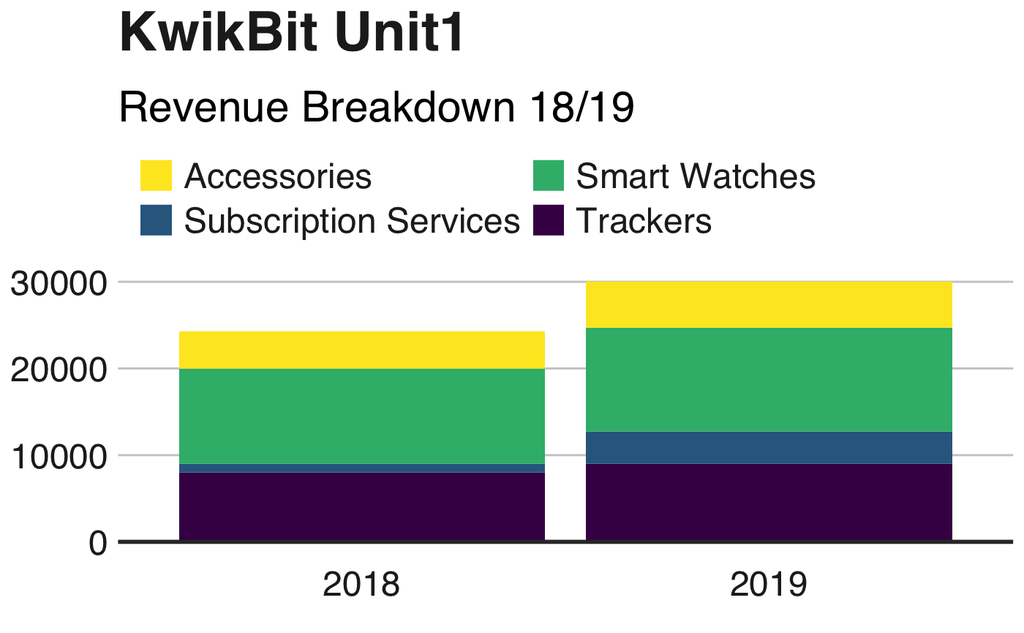

```r
ggplot(qb_revenue_breakdown, aes(fill = Product, y = Revenue, x = Year)) +
    geom_bar(position="stack", stat="identity") +
    bbc_style() +
  scale_fill_viridis_d(direction = -1) +
  geom_hline(yintercept = 0, size = 1, colour = "#333333") +
  labs(title = "KwikBit Unit1",
       subtitle = "Revenue Breakdown 18/19") +
  theme(legend.position = "top",
        legend.justification = "left") +
  guides(fill = guide_legend(nrow = 2, byrow = TRUE))
```

#2Make a line chart showing monthly sales of the “flagship product” - the KwikBit Unit1 - over the last year. This data is inside qb_monthly_sales, but you will need to use subset.

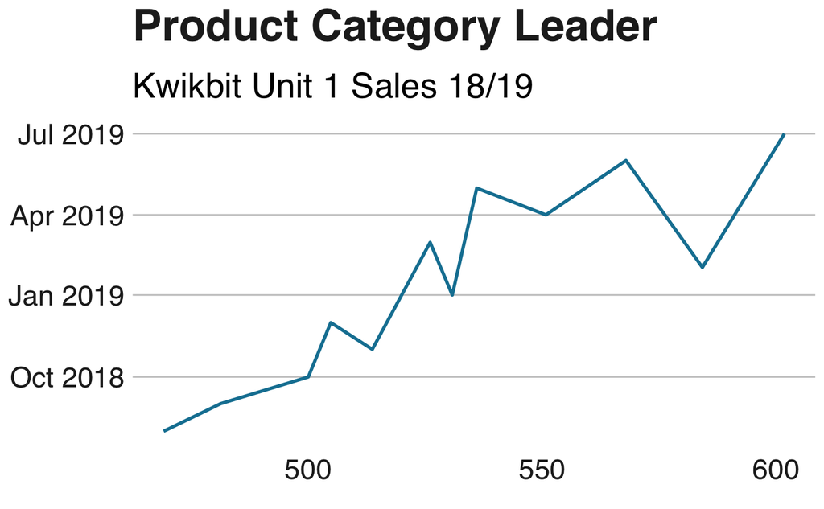

```r
#Done via filter
kb_sales <- qb_monthly_sales %>%
  filter(Cashflow == "Kwikbit Unit 1 Sales")

ggplot(kb_sales, aes(x = Amount, y = Date)) +
  geom_line(colour = "#1380A1", size = 1) +
  bbc_style() +
  labs(title="Product Category Leader",
       subtitle = "Kwikbit Unit 1 Sales 18/19")
```